# Activity Monitoring Data Analysis

## Background

It is now possible to collect a large amount of data about personal movement using activity monitoring devices such as a Fitbit, Nike Fuelband, or Jawbone Up. These type of devices are part of the “quantified self” movement – a group of enthusiasts who take measurements about themselves regularly to improve their health, to find patterns in their behavior, or because they are tech geeks. But these data remain under-utilized both because the raw data are hard to obtain and there is a lack of statistical methods and software for processing and interpreting the data.

This report makes use of data from a personal activity monitoring device. This device collects data at 5 minute intervals through out the day. The data consists of two months of data from an anonymous individual collected during the months of October and November, 2012 and include the number of steps taken in 5 minute intervals each day.

## Dataset

The data for this report can be downloaded from the here:https://d396qusza40orc.cloudfront.net/repdata%2Fdata%2Factivity.zip The variables included in this dataset are:

steps: Number of steps taking in a 5-minute interval (missing values are coded as NA)

date: The date on which the measurement was taken in YYYY-MM-DD format

interval: Identifier for the 5-minute interval in which measurement was taken

there are a total of 17,568 observations in this dataset.

## Loading and preprocessing the data

I load the dataset into R supposing that this dataset is in the current directory. No extra procedure is needed.

```r
data<-read.csv("activity.csv",na.strings = "NA",colClasses = c("integer","Date","integer"))
```

## What is mean total number of steps taken per day?

```r
## calculate  the total number of steps taken per day.
total<-tapply(data$step,data$date,sum,na.rm ="T")
total
```

```
## 2012-10-01 2012-10-02 2012-10-03 2012-10-04 2012-10-05 2012-10-06
##          0        126      11352      12116      13294      15420
## 2012-10-07 2012-10-08 2012-10-09 2012-10-10 2012-10-11 2012-10-12
##      11015          0      12811       9900      10304      17382
## 2012-10-13 2012-10-14 2012-10-15 2012-10-16 2012-10-17 2012-10-18
##      12426      15098      10139      15084      13452      10056
## 2012-10-19 2012-10-20 2012-10-21 2012-10-22 2012-10-23 2012-10-24
##      11829      10395       8821      13460       8918       8355
## 2012-10-25 2012-10-26 2012-10-27 2012-10-28 2012-10-29 2012-10-30
##       2492       6778      10119      11458       5018       9819
## 2012-10-31 2012-11-01 2012-11-02 2012-11-03 2012-11-04 2012-11-05
##      15414          0      10600      10571          0      10439
## 2012-11-06 2012-11-07 2012-11-08 2012-11-09 2012-11-10 2012-11-11
##       8334      12883       3219          0          0      12608
## 2012-11-12 2012-11-13 2012-11-14 2012-11-15 2012-11-16 2012-11-17
##      10765       7336          0         41       5441      14339
## 2012-11-18 2012-11-19 2012-11-20 2012-11-21 2012-11-22 2012-11-23
##      15110       8841       4472      12787      20427      21194
## 2012-11-24 2012-11-25 2012-11-26 2012-11-27 2012-11-28 2012-11-29
##      14478      11834      11162      13646      10183       7047
## 2012-11-30
##          0
```

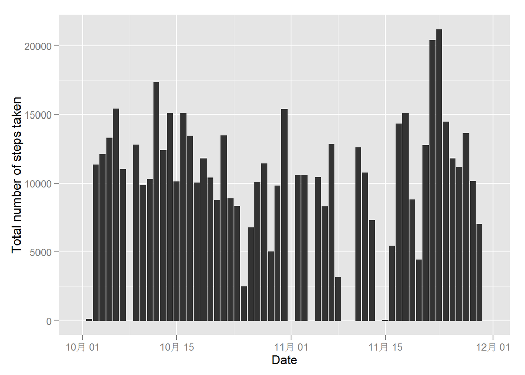

```r
library(ggplot2)
##make a histogram of the total number of steps taken each day
qplot(x=as.Date(names(total)),y=total,xlab = "Date",ylab = "Total number of steps taken",stat = "identity",geom = "histogram")
```

```r
##Calculate the mean and median of the total number of steps taken per day
c(mean(total),median(total))
```

```
## [1]  9354.23 10395.00
```

## What is the average daily activity pattern?

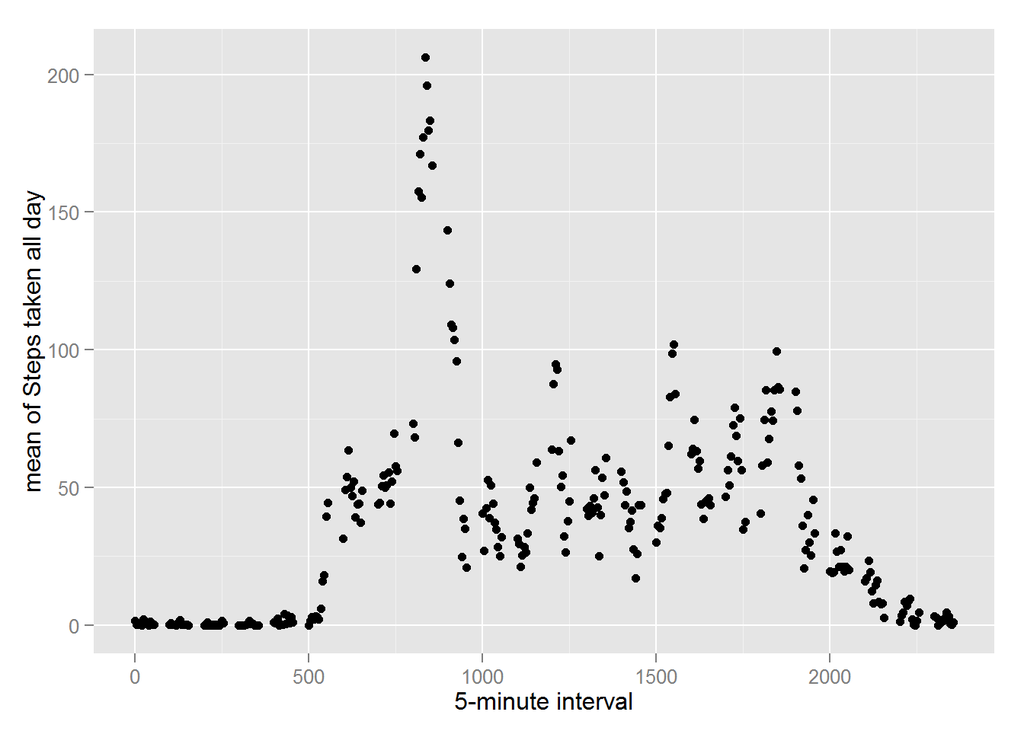

```r
## get the average number of steps taken per 5-minute interval
aver<-tapply(data$step,data$interval,mean,na.rm="T")
## make a time series plot (i.e. type = "l") of the 5-minute interval (x-axis) and the average number of steps taken, averaged across all days (y-axis)
qplot(x=as.integer(names(aver)),y=aver,xlab = "5-minute interval",ylab = "mean of Steps taken all day",type="l")
```

```r
## get the 5-minute interval which, on average across all the days in the dataset, contains the maximum number of steps
names(aver)[which(aver==max(aver))]
```

```
## [1] "835"
```

So the 835 5-minute interval contains the maxium number of steps.

## Imputing missing values

```r
## calculate and report the total number of missing values in the dataset
sum(is.na(data$step))
```

```
## [1] 2304
```

My filling stragety is imputing missing value by the mean for that interval because the data for a whole day may be missing, such as ‘2012-10-1’, however, I confirm that every interval has at least a single value.

```r
## filling in the missing value by the mean for that interval and create a new dataset that is equal to the original dataset but with the missing data filled in.
newData<-data
for(i in 1:dim(newData)[1])
{ if (is.na(newData$steps[i])) {
       newData$steps[i] =aver[which(newData$interval[i]==as.integer(names(aver)))]

}
}
## demonstrate that all missing value is filled
sum(is.na(newData$steps))
```

```
## [1] 0
```

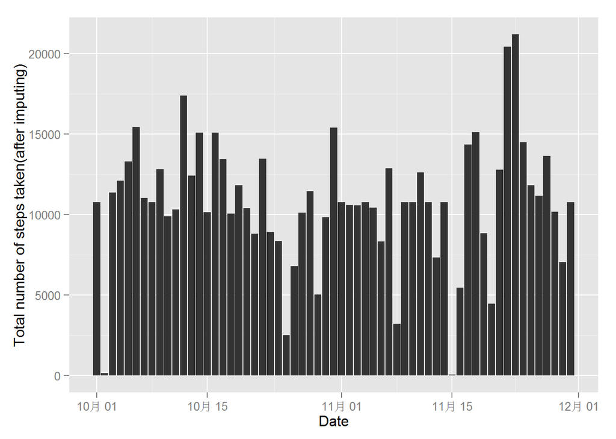

```r
## make a histogram of the total number of steps taken each day forthe new dataset
newTotal<-tapply(newData$step,newData$date,sum)
qplot(x=,as.Date(names(newTotal)),y=newTotal,xlab = "Date",ylab = "Total number of steps taken(after imputing)",stat = "identity",geom = "histogram")
```

```r
## calculate the mean and median total number of steps taken per day
c(mean(newTotal),median(newTotal))
```

```
## [1] 10766.19 10766.19
```

## Are there differences in activity patterns between weekdays and weekends?

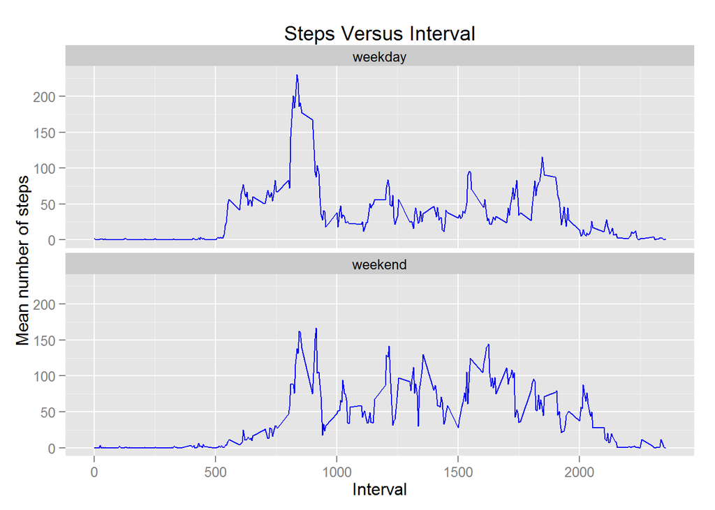

```r
## judge whether dates are weekdays
newData$weekday<-!(weekdays(newData$date) %in% c(weekdays(as.Date("2015-12-12")),weekdays(as.Date("2015-12-13"))))
##calcualte the mean number of steps group by interval and weekday(weekend)
newAver<-tapply(newData$steps,list(as.factor(newData$interval),as.factor(newData$weekday)),mean)
##transform  data frame newAver into averList
##initalization
k<- 1
averList<-data.frame(1:dim(newAver)[1],1:dim(newAver)[1],1:dim(newAver)[1])
for (i in 1:dim(newAver)[1]) {
  for (j in 1:dim(newAver)[2])
  {
    averList[k,1] = as.integer(rownames(newAver)[i])
    if (j%%2)    {
    averList[k,2] = "weekend"
    }
    else { averList[k,2] = "weekday"}
    averList[k,3] = newAver[i,j]
    k<-k+1
  }
}
names(averList)<-c("interval","weekday","steps")
## make a panel plot containing a time series plot of the 5-minute interval (x-axis) and the average number of steps taken, averaged across all weekday days or weekend days (y-axis)
ggplot(data=averList,aes(x=interval,y=steps),type="l")+geom_line(colour ='blue') +facet_wrap(~weekday,nrow=2,ncol=1)+labs(x="Interval")+labs(y="Mean number of steps")+labs(title ="Steps Versus Interval")
```